# R Notebook

1. Call libraries

```r
library(tidyverse)
library(here)
library(janitor)
library(GGally)
```

2. View data

```r
avocado <- read_csv(here("data/avocado.csv")) %>%
  clean_names()
```

```
* `` -> ...1
```

```r
glimpse(avocado)
```

```
Rows: 18,249
Columns: 14
$ x1            <dbl> 0, 1, 2, 3, 4, 5, 6, 7, 8, 9, 10, 11, 12, 13, 14, 15, 16, 17, 18, 19, 20, 21, 22, 23, 24, 25, 26, 27, 28, 29, 3~
$ date          <date> 2015-12-27, 2015-12-20, 2015-12-13, 2015-12-06, 2015-11-29, 2015-11-22, 2015-11-15, 2015-11-08, 2015-11-01, 20~
$ average_price <dbl> 1.33, 1.35, 0.93, 1.08, 1.28, 1.26, 0.99, 0.98, 1.02, 1.07, 1.12, 1.28, 1.31, 0.99, 1.33, 1.28, 1.11, 1.07, 1.3~
$ total_volume  <dbl> 64236.62, 54876.98, 118220.22, 78992.15, 51039.60, 55979.78, 83453.76, 109428.33, 99811.42, 74338.76, 84843.44,~
$ x4046         <dbl> 1036.74, 674.28, 794.70, 1132.00, 941.48, 1184.27, 1368.92, 703.75, 1022.15, 842.40, 924.86, 1582.03, 2268.32, ~
$ x4225         <dbl> 54454.85, 44638.81, 109149.67, 71976.41, 43838.39, 48067.99, 73672.72, 101815.36, 87315.57, 64757.44, 75595.85,~
$ x4770         <dbl> 48.16, 58.33, 130.50, 72.58, 75.78, 43.61, 93.26, 80.00, 85.34, 113.00, 117.07, 105.32, 101.36, 154.84, 150.50,~
$ total_bags    <dbl> 8696.87, 9505.56, 8145.35, 5811.16, 6183.95, 6683.91, 8318.86, 6829.22, 11388.36, 8625.92, 8205.66, 10123.90, 8~
$ small_bags    <dbl> 8603.62, 9408.07, 8042.21, 5677.40, 5986.26, 6556.47, 8196.81, 6266.85, 11104.53, 8061.47, 7877.86, 9866.27, 83~
$ large_bags    <dbl> 93.25, 97.49, 103.14, 133.76, 197.69, 127.44, 122.05, 562.37, 283.83, 564.45, 327.80, 257.63, 376.77, 145.59, 7~
$ x_large_bags  <dbl> 0.00, 0.00, 0.00, 0.00, 0.00, 0.00, 0.00, 0.00, 0.00, 0.00, 0.00, 0.00, 0.00, 0.00, 0.00, 0.00, 0.00, 0.00, 0.0~
$ type          <chr> "conventional", "conventional", "conventional", "conventional", "conventional", "conventional", "conventional",~
$ year          <dbl> 2015, 2015, 2015, 2015, 2015, 2015, 2015, 2015, 2015, 2015, 2015, 2015, 2015, 2015, 2015, 2015, 2015, 2015, 201~
$ region        <chr> "Albany", "Albany", "Albany", "Albany", "Albany", "Albany", "Albany", "Albany", "Albany", "Albany", "Albany", "~
```

3. Check for NA values

```r
avocado %>%
  summarise(across(.cols = everything(),
                   .fns = ~sum(is.na(.x))))
```

| x1 | date | average_price | total_volume | x4046 | x4225 | x4770 | total_bags | small_bags | large_bags | x_large_bags | type | year | region |
| --- | --- | --- | --- | --- | --- | --- | --- | --- | --- | --- | --- | --- | --- |
| 0 | 0 | 0 | 0 | 0 | 0 | 0 | 0 | 0 | 0 | 0 | 0 | 0 | 0 |

```r
NA
```

No missing values!

4. Data familiarisation

```r
avocado %>%
  distinct(year)
```

| year |
| --- |
| 2015 |
| 2016 |
| 2017 |
| 2018 |

This variable is categorical - should be represented as a factor

```r
avocado %>%
  distinct(type)
```

| type |
| --- |
| conventional |
| organic |

Variable `type` is categorical –> dummy variable!

```r
avocado %>%
  distinct(region)
```

| region |
| --- |
| Albany |
| Atlanta |
| BaltimoreWashington |
| Boise |
| Boston |
| BuffaloRochester |
| California |
| Charlotte |
| Chicago |
| CincinnatiDayton |

[output cut: 44 more lines]

There is region value that refers to the TotalUS - perhaps better to model this value rather than all of the region values together.

```r
avocado %>%
  group_by(year, type) %>%
  summarise(avg_mean_price = mean(average_price))
```

| year | type | avg_mean_price |
| --- | --- | --- |
| 2015 | conventional | 1.077963 |
| 2015 | organic | 1.673324 |
| 2016 | conventional | 1.105595 |
| 2016 | organic | 1.571684 |
| 2017 | conventional | 1.294888 |
| 2017 | organic | 1.735521 |
| 2018 | conventional | 1.127886 |
| 2018 | organic | 1.567176 |

Funny jump in avocado price in 2017 - needs further investigation?

```r
avocado %>%
  filter(region == "TotalUS") %>%
  arrange(date)
```

| x1 | date | average_price | total_volume | x4046 | x4225 | x4770 | total_bags | small_bags | large_bags | x_large_bags | type | year | region |
| --- | --- | --- | --- | --- | --- | --- | --- | --- | --- | --- | --- | --- | --- |
| 51 | 2015-01-04 | 0.95 | 31324277.7 | 12357161.34 | 13624083.1 | 844093.32 | 4498940.0 | 3585321.58 | 894945.63 | 18672.81 | conventional | 2015 | TotalUS |
| 51 | 2015-01-04 | 1.46 | 612910.2 | 233286.13 | 216611.2 | 4370.99 | 158641.8 | 115068.71 | 43573.12 | 0.00 | organic | 2015 | TotalUS |
| 50 | 2015-01-11 | 1.01 | 29063542.8 | 11544810.53 | 12134773.4 | 866574.66 | 4517384.2 | 3783261.16 | 718333.87 | 15789.15 | conventional | 2015 | TotalUS |
| 50 | 2015-01-11 | 1.42 | 669528.9 | 270966.74 | 260971.6 | 3830.42 | 133760.1 | 106844.49 | 26915.63 | 0.00 | organic | 2015 | TotalUS |
| 49 | 2015-01-18 | 1.03 | 29043458.9 | 11858139.34 | 11701947.8 | 831301.90 | 4652069.8 | 3873041.26 | 771093.20 | 7935.35 | conventional | 2015 | TotalUS |
| 49 | 2015-01-18 | 1.42 | 713120.0 | 254319.58 | 311811.0 | 4020.85 | 142968.6 | 101850.23 | 41118.33 | 0.00 | organic | 2015 | TotalUS |
| 48 | 2015-01-25 | 1.04 | 28470310.8 | 12167445.03 | 10734652.8 | 768020.05 | 4800192.9 | 3978636.90 | 812924.73 | 8631.31 | conventional | 2015 | TotalUS |
| 48 | 2015-01-25 | 1.53 | 556368.9 | 207494.87 | 212312.0 | 4753.87 | 131808.1 | 95964.83 | 35843.27 | 0.00 | organic | 2015 | TotalUS |
| 47 | 2015-02-01 | 0.89 | 44655461.5 | 18933038.04 | 18956479.7 | 1381516.11 | 5384427.6 | 4216452.03 | 1121076.47 | 46899.12 | conventional | 2015 | TotalUS |
| 47 | 2015-02-01 | 1.36 | 740897.0 | 302561.47 | 259286.4 | 5852.28 | 173196.8 | 129953.15 | 43243.63 | 0.00 | organic | 2015 | TotalUS |

[output cut: 328 more lines]

```r
avocado %>%
  filter(region == "TotalUS") %>%
  group_by(year, type) %>%
  summarise(avg_mean_price = mean(average_price))
```

| year | type | avg_mean_price |
| --- | --- | --- |
| 2015 | conventional | 1.012500 |
| 2015 | organic | 1.502308 |
| 2016 | conventional | 1.046731 |
| 2016 | organic | 1.480385 |
| 2017 | conventional | 1.221698 |
| 2017 | organic | 1.651509 |
| 2018 | conventional | 1.060000 |
| 2018 | organic | 1.554167 |

Funny jump in avocado price in 2017. I saw this previously when considered all regions - needs further investigation?

4.1 View data as time series:

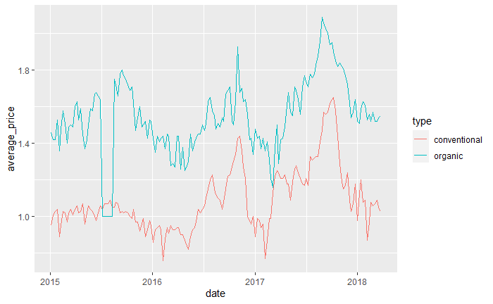

```r
avocado %>%
  filter(region == "TotalUS") %>%
  ggplot() +
  geom_line(aes(x = date, y = average_price, group = type, color = type))
```

Country-wide there’s a seasonality in the avocado price - it peaks around September. The average price during this time of the year has been increasing as seen in the data for 2015-2017.

There were 6 consecutive weeks in 2015 (2015-07-05 to 2015-08-09) where the `organic` avocado price was stuck at 1.00. This value does not look normal as seen in the trend plot above. Perhaps better to replace these values with the value from 2015-06-28 (ie 1.64) or the average of avocado prices between 2015-06-28 and 2015-08-16 (ie average of 1.64 and 1.75).

NB: For the `conventional` avocado price, the price between 2015-07-12 and 2015-07-26 was 1.07. It is likely that these values were imputed, too.

4.2 Check of trends for other variables

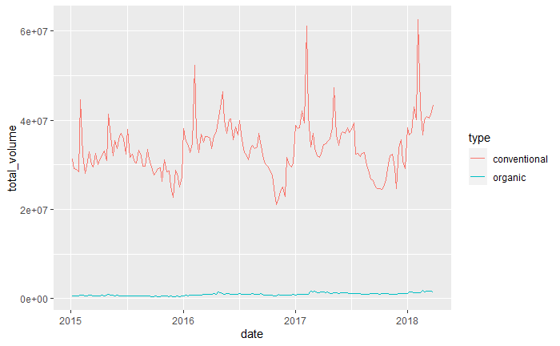

```r
avocado %>%
  filter(region == "TotalUS") %>%
  ggplot() +
  geom_line(aes(x = date, y = total_volume, group = type, color = type))
```

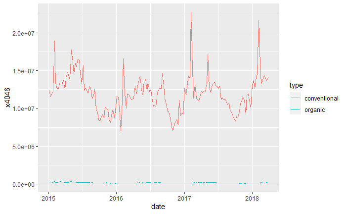

```r
avocado %>%
  filter(region == "TotalUS") %>%
  ggplot() +
  geom_line(aes(x = date, y = x4046, group = type, color = type))
```

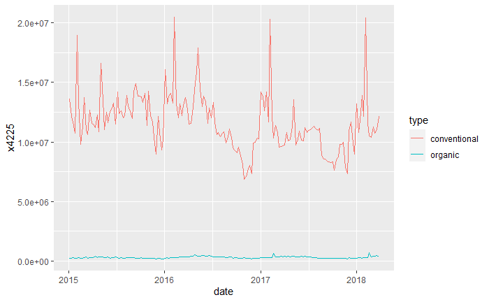

```r
avocado %>%
  filter(region == "TotalUS") %>%
  ggplot() +
  geom_line(aes(x = date, y = x4225, group = type, color = type))
```

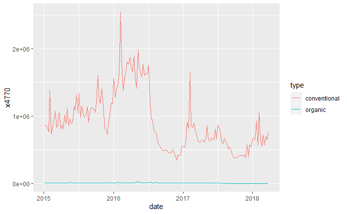

```r
avocado %>%
  filter(region == "TotalUS") %>%
  ggplot() +
  geom_line(aes(x = date, y = x4770, group = type, color = type))
```

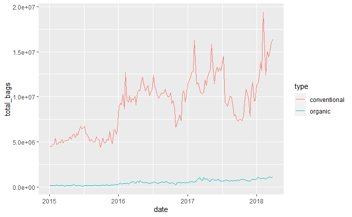

```r
avocado %>%
  filter(region == "TotalUS") %>%
  ggplot() +
  geom_line(aes(x = date, y = total_bags, group = type, color = type))
```

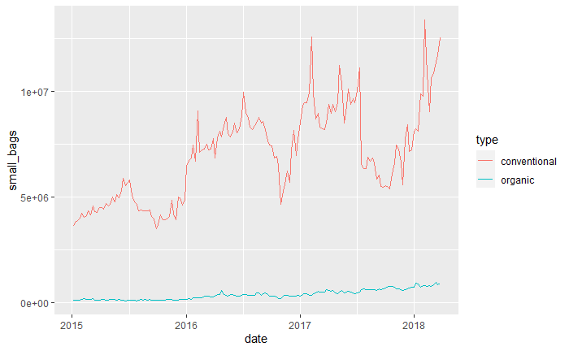

```r
avocado %>%
  filter(region == "TotalUS") %>%
  ggplot() +
  geom_line(aes(x = date, y = small_bags, group = type, color = type))
```

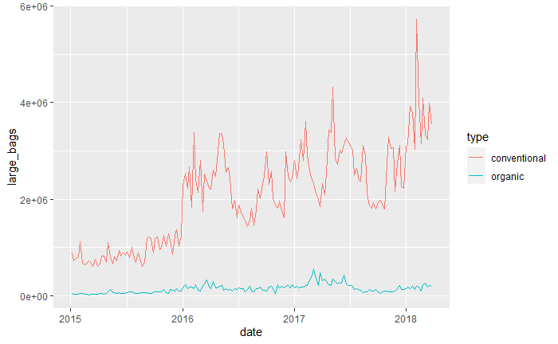

```r
avocado %>%
  filter(region == "TotalUS") %>%
  ggplot() +
  geom_line(aes(x = date, y = large_bags, group = type, color = type))
```

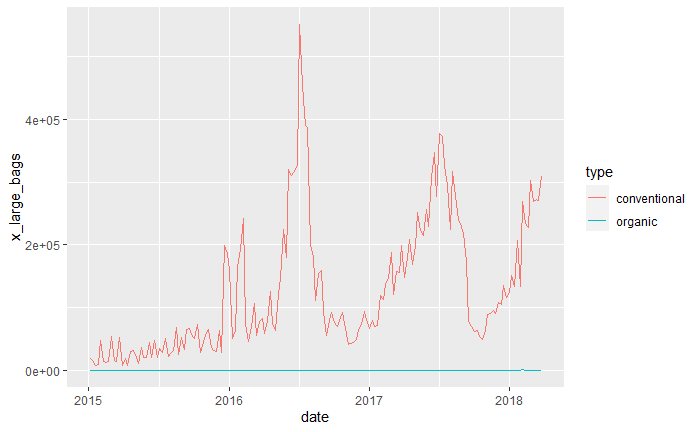

```r
avocado %>%
  filter(region == "TotalUS") %>%
  ggplot() +
  geom_line(aes(x = date, y = x_large_bags, group = type, color = type))
```

The values corresponding to `conventional` type avocados are many orders of magnitude higher than the `organic` type avocados. We have to scale the data!!!

4.3 Check of avocado price trends for other regions:

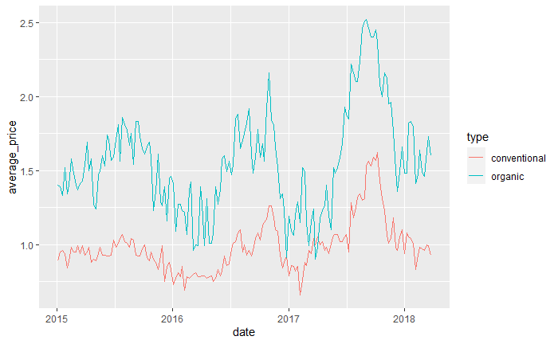

```r
avocado %>%
  filter(region == "West") %>%
  ggplot() +
  geom_line(aes(x = date, y = average_price, group = type, color = type))
```

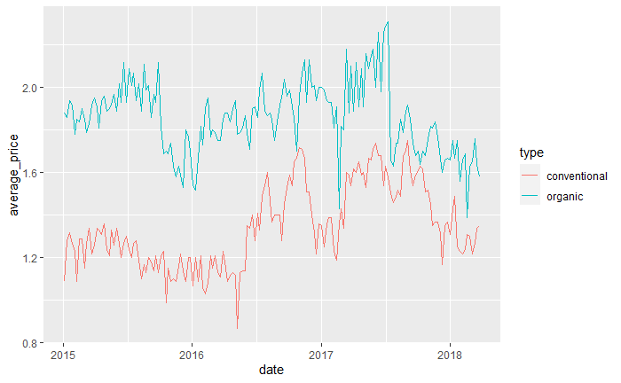

```r
avocado %>%
  filter(region == "Northeast") %>%
  ggplot() +
  geom_line(aes(x = date, y = average_price, group = type, color = type))
```

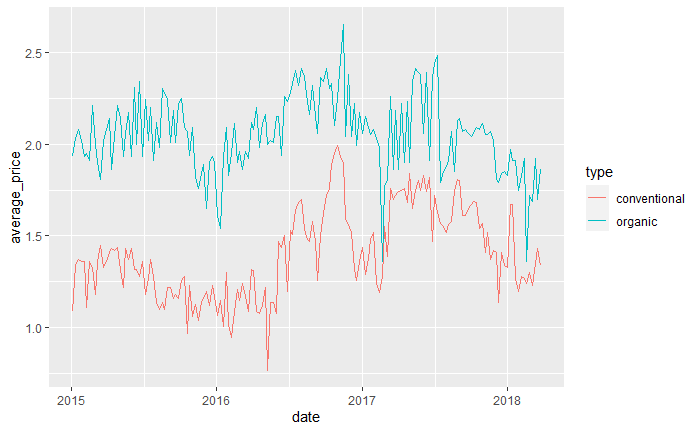

```r
avocado %>%
  filter(region == "NewYork") %>%
  ggplot() +
  geom_line(aes(x = date, y = average_price, group = type, color = type))
```

5. Modeling Objective

Model the avocado `average_price` for region `TotalUS` for available data of years 2015-2018

Stuff to do to the data set:

1. Variable `type` is categorical –> dummy variable! Have to make it a factor!
2. Variable `year` is categorical –> should be represented as a factor
3. `total_bags` equals `small_bags` + `large_bags` + `x_large_bags`. We can drop `total_bags`
4. The values corresponding to `conventional` type avocados are many orders of magnitude higher than the `organic` type avocados. We have to scale data!!!
5. Country-wide there’s a seasonality in the avocado price - it peaks around September. The average price during this time of the year has been increasing as seen in the data for 2015-2017.

There were 6 consecutive weeks in 2015 (2015-07-05 to 2015-08-09) where the `organic` avocado price was stuck at 1.00. This value does not look normal as seen in the trend plot above. Perhaps better to replace these values with the value from 2015-06-28 (ie 1.64) or the average of avocado prices between 2015-06-28 and 2015-08-16 (ie average of 1.64 and 1.75).

NB: For the `conventional` avocado price, the price between 2015-07-12 and 2015-07-26 was 1.07. It is likely that these values were imputed, too.

5.1 Tidy data set

```r
impute_value <- avocado$average_price[avocado$date == "2015-06-28" & avocado$region == "TotalUS" & avocado$type == "organic"]

avocado_tidy <- avocado %>%
  filter(region == "TotalUS") %>%
  mutate(year = as.factor(year),
         average_price = ifelse(
           type == "organic" & average_price == 1,
           impute_value,
           average_price),
  ) %>%
  mutate(across(.cols = total_volume:x_large_bags, .fns = ~scale(.x))) %>%
  select(-c(x1, date, region, total_bags))
```

5.2 Check for aliases

```r
alias(average_price ~ ., data = avocado_tidy)
```

```
Model :
average_price ~ total_volume + x4046 + x4225 + x4770 + small_bags +
    large_bags + x_large_bags + type + year
```

Ok, no aliases occurring to data set!

5.3 Check associations of potential predictors

Split data in numeric and non-numeric

```r
avocado_tidy_numeric <- avocado_tidy %>%
  select_if(is.numeric)

avocado_tidy_nonnumeric <- avocado_tidy %>%
  select_if(function(x) !is.numeric(x))

avocado_tidy_nonnumeric$average_price <- avocado_tidy$average_price
```

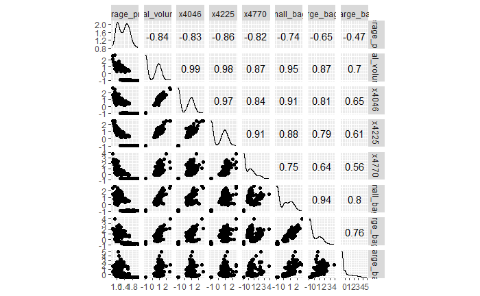

```r
avocado_tidy_numeric %>%
  ggscatmat()
```

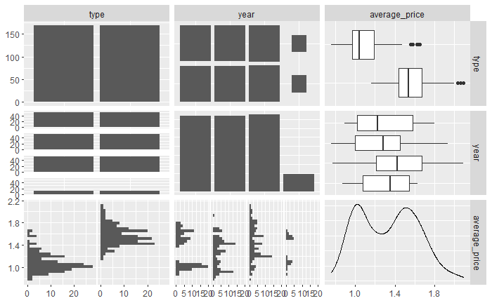

```r
avocado_tidy_nonnumeric %>%
  ggpairs()
```

# Automated Modeling

```r
library(leaps)
```

1. Forward search

```r
regsubsets_forward <- regsubsets(average_price ~ ., data = avocado_tidy, nvmax = 9, method = "forward")
```

```r
sum_regsubsets_forward <- summary(regsubsets_forward)
sum_regsubsets_forward
```

```
Subset selection object
Call: regsubsets.formula(average_price ~ ., data = avocado_tidy, nvmax = 9,
    method = "forward")
11 Variables  (and intercept)
             Forced in Forced out
total_volume     FALSE      FALSE
x4046            FALSE      FALSE
x4225            FALSE      FALSE
x4770            FALSE      FALSE
small_bags       FALSE      FALSE
large_bags       FALSE      FALSE
x_large_bags     FALSE      FALSE
typeorganic      FALSE      FALSE
year2016         FALSE      FALSE
year2017         FALSE      FALSE
year2018         FALSE      FALSE
1 subsets of each size up to 9
Selection Algorithm: forward
         total_volume x4046 x4225 x4770 small_bags large_bags x_large_bags typeorganic year2016 year2017 year2018
1  ( 1 ) " "          " "   "*"   " "   " "        " "        " "          " "         " "      " "      " "
2  ( 1 ) " "          " "   "*"   " "   " "        " "        " "          " "         " "      "*"      " "
3  ( 1 ) " "          " "   "*"   " "   " "        " "        " "          " "         "*"      "*"      " "
4  ( 1 ) " "          " "   "*"   " "   " "        " "        "*"          " "         "*"      "*"      " "
5  ( 1 ) "*"          " "   "*"   " "   " "        " "        "*"          " "         "*"      "*"      " "
6  ( 1 ) "*"          " "   "*"   "*"   " "        " "        "*"          " "         "*"      "*"      " "
7  ( 1 ) "*"          " "   "*"   "*"   " "        " "        "*"          "*"         "*"      "*"      " "
8  ( 1 ) "*"          " "   "*"   "*"   " "        " "        "*"          "*"         "*"      "*"      "*"
9  ( 1 ) "*"          "*"   "*"   "*"   " "        " "        "*"          "*"         "*"      "*"      "*"
```

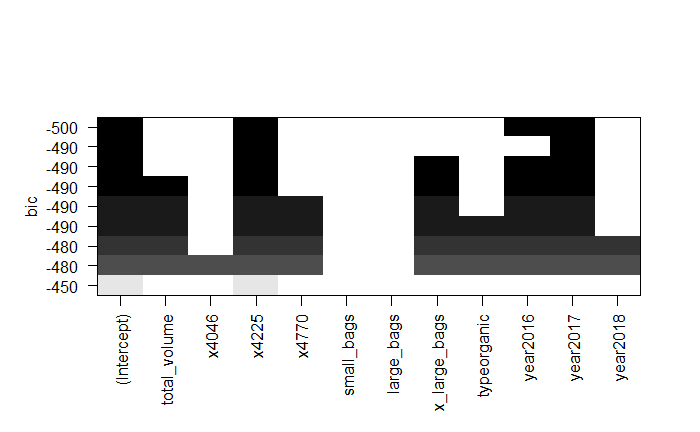

```r
plot(regsubsets_forward, scale = "bic")
```

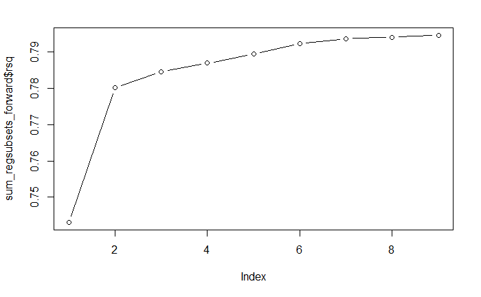

```r
plot(sum_regsubsets_forward$rsq, type = "b")
```

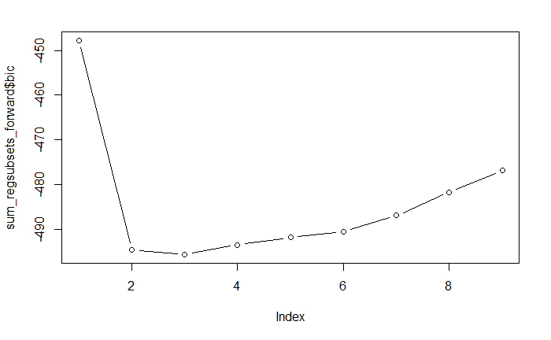

```r
plot(sum_regsubsets_forward$bic, type = "b")
```

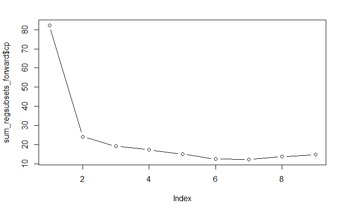

```r
plot(sum_regsubsets_forward$cp, type = "b")
```

Go ahead and extract the 3-predictor model, and then check its significance and the diagnostic plots.

```r
summary(regsubsets_forward)$which[3,]
```

```
 (Intercept) total_volume        x4046        x4225        x4770   small_bags   large_bags x_large_bags  typeorganic     year2016
        TRUE        FALSE        FALSE         TRUE        FALSE        FALSE        FALSE        FALSE        FALSE         TRUE
    year2017     year2018
        TRUE        FALSE
```

```r
mod_with_year <- lm(average_price ~ x4225 + year, data = avocado_tidy)
summary(mod_with_year)
```

```
Call:
lm(formula = average_price ~ x4225 + year, data = avocado_tidy)

Residuals:
     Min       1Q   Median       3Q      Max
-0.49269 -0.07489 -0.01109  0.08606  0.43205

Coefficients:
             Estimate Std. Error t value Pr(>|t|)
(Intercept)  1.311207   0.013526  96.937  < 2e-16 ***
x4225       -0.251603   0.007524 -33.439  < 2e-16 ***
year2016    -0.045340   0.019121  -2.371   0.0183 *
year2017     0.103323   0.019061   5.421 1.14e-07 ***
year2018     0.010215   0.031216   0.327   0.7437
---
Signif. codes:  0 ‘***’ 0.001 ‘**’ 0.01 ‘*’ 0.05 ‘.’ 0.1 ‘ ’ 1

Residual standard error: 0.1378 on 333 degrees of freedom
Multiple R-squared:  0.7847,    Adjusted R-squared:  0.7821
F-statistic: 303.3 on 4 and 333 DF,  p-value: < 2.2e-16
```

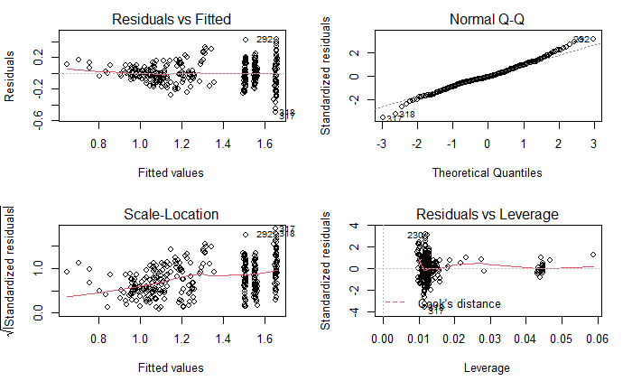

```r
par(mfrow = c(2, 2))
plot(mod_with_year)
```

2. Exhaustive search

```r
regsubsets_exhaustive <- regsubsets(average_price ~ ., data = avocado_tidy, nvmax = 9, method = "exhaustive")
```

```r
sum_regsubsets_exhaustive <- summary(regsubsets_exhaustive)
sum_regsubsets_exhaustive
```

```
Subset selection object
Call: regsubsets.formula(average_price ~ ., data = avocado_tidy, nvmax = 9,
    method = "exhaustive")
11 Variables  (and intercept)
             Forced in Forced out
total_volume     FALSE      FALSE
x4046            FALSE      FALSE
x4225            FALSE      FALSE
x4770            FALSE      FALSE
small_bags       FALSE      FALSE
large_bags       FALSE      FALSE
x_large_bags     FALSE      FALSE
typeorganic      FALSE      FALSE
year2016         FALSE      FALSE
year2017         FALSE      FALSE
year2018         FALSE      FALSE
1 subsets of each size up to 9
Selection Algorithm: exhaustive
         total_volume x4046 x4225 x4770 small_bags large_bags x_large_bags typeorganic year2016 year2017 year2018
1  ( 1 ) " "          " "   "*"   " "   " "        " "        " "          " "         " "      " "      " "
2  ( 1 ) " "          " "   "*"   " "   " "        " "        " "          " "         " "      "*"      " "
3  ( 1 ) " "          " "   "*"   " "   " "        " "        " "          " "         "*"      "*"      " "
4  ( 1 ) "*"          " "   " "   "*"   " "        " "        "*"          " "         " "      "*"      " "
5  ( 1 ) "*"          " "   " "   "*"   " "        " "        "*"          " "         "*"      "*"      " "
6  ( 1 ) "*"          " "   "*"   "*"   " "        " "        "*"          " "         "*"      "*"      " "
7  ( 1 ) "*"          " "   "*"   "*"   " "        " "        "*"          "*"         "*"      "*"      " "
8  ( 1 ) "*"          "*"   "*"   "*"   "*"        "*"        "*"          " "         " "      "*"      " "
9  ( 1 ) "*"          "*"   "*"   "*"   "*"        "*"        "*"          "*"         " "      "*"      " "
```

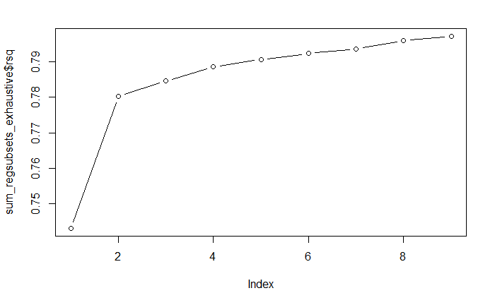

```r
plot(sum_regsubsets_exhaustive$rsq, type = "b")
```

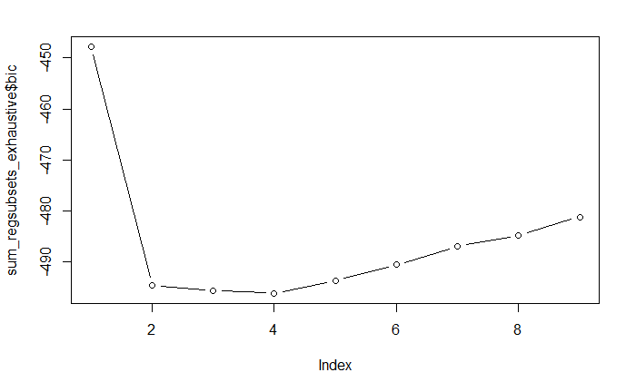

```r
plot(sum_regsubsets_exhaustive$bic, type = "b")
```

Go ahead and extract the 4-predictor model, and then check its significance and the diagnostic plots.

```r
summary(regsubsets_exhaustive)$which[4,]
```

```
 (Intercept) total_volume        x4046        x4225        x4770   small_bags   large_bags x_large_bags  typeorganic     year2016
        TRUE         TRUE        FALSE        FALSE         TRUE        FALSE        FALSE         TRUE        FALSE        FALSE
    year2017     year2018
        TRUE        FALSE
```

```r
mod_exhaustive_with_year <- lm(average_price ~ total_volume + x4770 + x_large_bags + type + year, data = avocado_tidy)
summary(mod_exhaustive_with_year)
```

```
Call:
lm(formula = average_price ~ total_volume + x4770 + x_large_bags +
    type + year, data = avocado_tidy)

Residuals:
     Min       1Q   Median       3Q      Max
-0.48194 -0.07357 -0.00171  0.07328  0.43885

Coefficients:
             Estimate Std. Error t value Pr(>|t|)
(Intercept)   1.33916    0.03192  41.955  < 2e-16 ***
total_volume -0.27089    0.03796  -7.136 6.14e-12 ***
x4770        -0.05846    0.01710  -3.419 0.000706 ***
x_large_bags  0.04996    0.01123   4.448 1.19e-05 ***
typeorganic  -0.07911    0.06229  -1.270 0.204979
year2016     -0.02565    0.01975  -1.299 0.194769
year2017      0.11407    0.02167   5.264 2.55e-07 ***
year2018      0.04076    0.03547   1.149 0.251250
---
Signif. codes:  0 ‘***’ 0.001 ‘**’ 0.01 ‘*’ 0.05 ‘.’ 0.1 ‘ ’ 1

Residual standard error: 0.1361 on 330 degrees of freedom
Multiple R-squared:  0.7921,    Adjusted R-squared:  0.7877
F-statistic: 179.6 on 7 and 330 DF,  p-value: < 2.2e-16
```

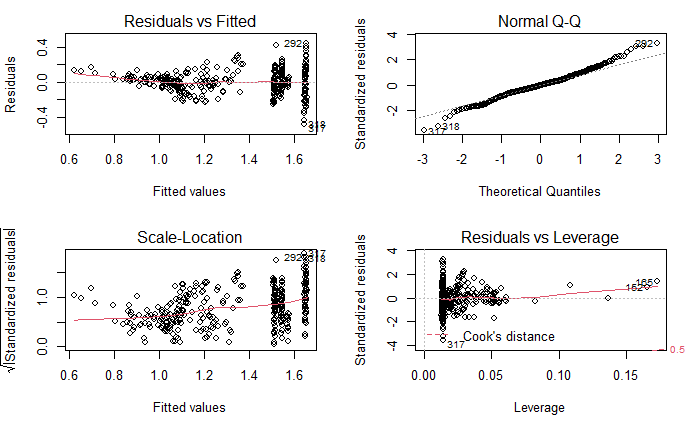

```r
par(mfrow = c(2, 2))
plot(mod_exhaustive_with_year)
```

3. Use the `gmulti` package

```r
library(glmulti)
glmulti_fit <- glmulti(
  average_price ~ .,
  data = avocado_tidy,
  level = 2, # 2 = include pairwise interactions, 1 = main effects only (main effect = no pairwise interactions)
  minsize = 0, # no min size of model
  maxsize = -1, # -1 = no max size of model
  marginality = TRUE, # marginality here means the same as 'strongly hierarchical' interactions, i.e. include pairwise interactions only if both predictors present in the model as main effects.
  method = "g", # the problem is too large for exhaustive search, so search using a genetic algorithm
  crit = bic, # criteria for model selection is BIC value (lower is better)
  plotty = FALSE, # don't plot models as function runs
  report = TRUE, # do produce reports as function runs
  confsetsize = 100, # return best 100 solutions
  fitfunction = lm # fit using the `lm` function
)
```

[output not shown]

[output cut: 509 more lines]

[output not shown]

```r
summary(glmulti_fit)
```

```
$name
[1] "glmulti.analysis"

$method
[1] "g"

$fitting
[1] "lm"

$crit
[1] "bic"

$level
[1] 2

$marginality
[1] TRUE

$confsetsize
[1] 100

$bestic
[1] -499.8578

$icvalues
  [1] -499.8578 -499.5355 -499.2289 -498.4031 -497.4015 -497.1643 -497.1033 -496.6954 -495.5998 -494.8110 -494.2253 -494.2097 -494.2085
 [14] -494.1705 -494.1262 -494.1191 -494.1191 -494.0588 -493.9586 -493.8808 -493.8374 -492.6436 -492.3125 -491.6790 -491.5908 -491.1342
 [27] -490.1424 -489.9081 -489.6272 -488.8614 -488.4670 -488.2570 -488.2411 -488.2135 -488.0486 -487.7733 -487.0658 -486.5509 -483.7222
 [40] -483.5542 -483.1875 -482.4427 -481.1179 -480.9846 -480.7687 -478.0627 -477.5838 -477.0175 -476.3280 -475.3513 -474.3656 -474.2214
 [53] -473.5238 -473.2496 -472.3449 -471.8585 -469.0652 -467.8747 -466.6846 -466.2887 -466.2715 -466.1618 -465.4630 -465.1504 -463.5127
 [66] -463.3935 -462.7025 -462.6594 -462.4882 -461.7354 -461.6883 -461.3840 -461.2755 -460.5167 -460.4497 -460.4208 -459.8296 -459.8210
 [79] -459.7757 -459.5927 -459.0012 -458.5388 -458.4938 -458.2496 -458.2415 -458.2189 -458.1488 -457.9749 -457.8751 -457.8193 -457.7282
 [92] -456.6753 -456.6261 -456.4506 -455.5683 -455.4560 -455.4218 -455.1514 -454.9799 -454.4617

$bestmodel
[1] "average_price ~ 1 + year + total_volume + x4046 + x4225 + x4770 + "
[2] "    small_bags + large_bags + type + small_bags:total_volume + "
[3] "    small_bags:x4225 + large_bags:total_volume + large_bags:x4046 + "
[4] "    type:total_volume + type:x4225 + type:x4770 + type:small_bags + "
[5] "    year:small_bags + year:type"

$modelweights
  [1] 1.987713e-01 1.691831e-01 1.451371e-01 9.604154e-02 5.820787e-02 5.169665e-02 5.014462e-02 4.089232e-02 2.364533e-02 1.593890e-02
 [11] 1.189221e-02 1.180024e-02 1.179308e-02 1.157092e-02 1.131764e-02 1.127736e-02 1.127724e-02 1.094231e-02 1.040775e-02 1.001088e-02
 [21] 9.795728e-03 5.392725e-03 4.569927e-03 3.329301e-03 3.185636e-03 2.535408e-03 1.544104e-03 1.373436e-03 1.193482e-03 8.137814e-04
 [31] 6.681620e-04 6.015384e-04 5.967836e-04 5.886033e-04 5.420165e-04 4.723290e-04 3.315844e-04 2.563292e-04 6.230821e-05 5.728983e-05
 [41] 4.769259e-05 3.286342e-05 1.694513e-05 1.585230e-05 1.422984e-05 3.677933e-06 2.894746e-06 2.180927e-06 1.544968e-06 9.480543e-07
 [51] 5.791387e-07 5.388660e-07 3.801802e-07 3.314785e-07 2.108638e-07 1.653389e-07 4.091008e-08 2.255907e-08 1.244185e-08 1.020757e-08
 [61] 1.011989e-08 9.579712e-09 6.754862e-09 5.777476e-09 2.547478e-09 2.400081e-09 1.698953e-09 1.662732e-09 1.526300e-09 1.047566e-09
 [71] 1.023155e-09 8.787501e-10 8.323446e-10 5.695752e-10 5.507910e-10 5.428934e-10 4.039591e-10 4.022296e-10 3.932194e-10 3.588441e-10
 [81] 2.669609e-10 2.118597e-10 2.071412e-10 1.833345e-10 1.825983e-10 1.805414e-10 1.743233e-10 1.598106e-10 1.520264e-10 1.478424e-10
 [91] 1.412642e-10 8.344254e-11 8.141712e-11 7.457742e-11 4.797413e-11 4.535589e-11 4.458663e-11 3.894669e-11 3.574767e-11 2.758827e-11

$generations
[1] 930

$elapsed
[1] 0.03468603

$includeobjects
[1] TRUE
```

```r
# here is the best model (lowest BIC) from the glmulti run above
mod_interact <- lm(average_price ~ 1 + year + total_volume + x4046 + x4225 + x4770 +
                     small_bags + large_bags + type + small_bags:total_volume +
                     small_bags:x4225 + large_bags:total_volume + large_bags:x4046 +
                     type:total_volume + type:x4225 + type:x4770 + type:small_bags +
                     year:small_bags + year:type,
                     data = avocado_tidy)
summary(mod_interact)
```

```
Call:
lm(formula = average_price ~ 1 + year + total_volume + x4046 +
    x4225 + x4770 + small_bags + large_bags + type + small_bags:total_volume +
    small_bags:x4225 + large_bags:total_volume + large_bags:x4046 +
    type:total_volume + type:x4225 + type:x4770 + type:small_bags +
    year:small_bags + year:type, data = avocado_tidy)

Residuals:
      Min        1Q    Median        3Q       Max
-0.260890 -0.057783  0.000947  0.057062  0.300450

Coefficients:
                          Estimate Std. Error t value Pr(>|t|)
(Intercept)                1.08385    0.05799  18.691  < 2e-16 ***
year2016                   0.61126    0.09204   6.641 1.38e-10 ***
year2017                   0.92458    0.09908   9.332  < 2e-16 ***
year2018                   1.34906    0.22085   6.108 2.98e-09 ***
total_volume               6.84462    1.93410   3.539 0.000463 ***
x4046                     -2.62221    0.69625  -3.766 0.000198 ***
x4225                     -2.30353    0.68067  -3.384 0.000805 ***
x4770                     -0.30998    0.06933  -4.471 1.09e-05 ***
small_bags                -1.41834    0.45567  -3.113 0.002025 **
large_bags                -0.69406    0.14063  -4.935 1.30e-06 ***
typeorganic               -9.63821    1.30278  -7.398 1.28e-12 ***
total_volume:small_bags    0.75804    0.13502   5.614 4.35e-08 ***
x4225:small_bags          -0.59389    0.10774  -5.512 7.42e-08 ***
total_volume:large_bags    0.37312    0.08863   4.210 3.35e-05 ***
x4046:large_bags          -0.31903    0.07983  -3.996 8.03e-05 ***
total_volume:typeorganic -15.73652    2.13596  -7.367 1.56e-12 ***
x4225:typeorganic          5.30220    1.37121   3.867 0.000134 ***
x4770:typeorganic         -4.82391    1.45145  -3.324 0.000994 ***
small_bags:typeorganic     4.85312    0.58578   8.285 3.50e-15 ***
year2016:small_bags       -0.66515    0.13890  -4.789 2.59e-06 ***
year2017:small_bags       -0.85442    0.15055  -5.675 3.16e-08 ***
year2018:small_bags       -1.13557    0.20713  -5.482 8.65e-08 ***
year2016:typeorganic      -1.27996    0.21056  -6.079 3.52e-09 ***
year2017:typeorganic      -1.62838    0.23131  -7.040 1.22e-11 ***
year2018:typeorganic      -2.41715    0.39152  -6.174 2.07e-09 ***
---
Signif. codes:  0 ‘***’ 0.001 ‘**’ 0.01 ‘*’ 0.05 ‘.’ 0.1 ‘ ’ 1

Residual standard error: 0.09595 on 313 degrees of freedom
Multiple R-squared:  0.9019,    Adjusted R-squared:  0.8944
F-statistic: 119.9 on 24 and 313 DF,  p-value: < 2.2e-16
```

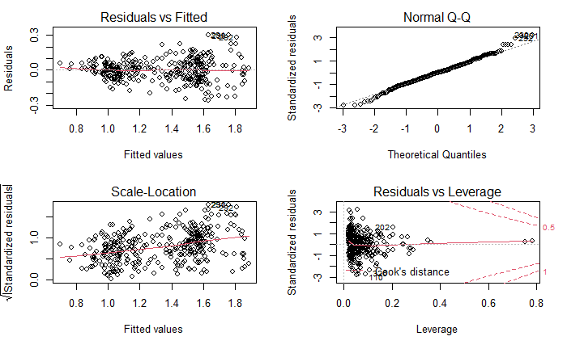

```r
# let's see diagnostic plots
par(mfrow = c(2, 2))
plot(mod_interact)
```

```r
# calculate predictor importances. This will take a while to run, as lmg tries all possible orders of including predictors!
# library(relaimpo)
# calc.relimp(mod_interact, type = "lmg", rela = TRUE)
```